# Network segregation, Social Isolation and Preference for Redistribution across societies

Julio Iturra-Sanhueza

10 octubre 2023

# Introduction

The escalating economic inequality and the current sanitary crisis have threatened social cohesion among citizens. However, these consequences have been unevenly experienced across the social structure. The upper and intermediate classes, benefiting from privileged access to social resources, have shown resilience. Conversely, working-class families have faced deteriorating material conditions, leading to a heightened sense of marginalisation and increasing the demand for welfare support. Particularly, social resources through network ties have been suggested to have a direct link with an individual’s welfare through instrumental and expressive outcomes, such as providing information or help in moments of need. Consequently, inequalities in access to certain social positions (i.e. occupations) are translated into a lack of social resources beyond individual economic and cultural capital. Additionally, it has been argued that social isolation not only plays a role in terms of resources but given that higher levels of segregation can bolster opinions, it is argued that being isolated from other social classes can polarise attitudes mainly in the working and upper-middle classes. Employing data from the International Social Survey Programme - Social Networks this research aims to understand to what extent the demand for redistribution is linked to social ties. To addresss this, ego-centred social networks are used to represent the degree of class-based homogeneity of social ties. The results of multilevel estimations show that being socially segregated increases demand for redistribution. Additionally, this influence is conditional to social class, where the working and intermediate classes with highly homogeneous networks demand more governmental redistribution than the upper class. At the macro level, as the current distribution of economic resources influences the opportunity structure, it has been hypothesised that income inequality could bolster the influence of social segregation on the demand for redistribution. However, cross-level interactions do not provide supporting evidence on this behalf.

## Class interests and redistribution

The following paragraph will briefly present the class-preference link. While previous research have focus more extensevely on the economic dimension of social class such as employment relations and occupation, the focus of this research is idea to argue that the patterns of social interactions (social ties) are also a constituent dimension of how classes shape their interests.

- The “Democratic” class struggle (Edlund & Lindh, 2015)
- Class interests in the economic domain (Lindh & McCall, 2020)
- The moral economy of class - the attitudinal domain of redistribution and the role of the state (Svallfors, 2006)

## Class-based inequality in social networks

This section will review the state of the art on the link between class/status and social networks, particularly the existing literature on the different forms of social capital.

Recent studies have focused on social capital formation processes (Volker, 2020), concentrating on structural processes, such as intergenerational social mobility and class inequalities, demonstrating how meeting opportunities and association preferences are stratified (Lin & Erickson, 2008). Consequently, access to higher and diverse resources through social ties follows a pattern of accumulation that reproduces pre-existing inequalities, in which class positions are vital in accounting for mechanisms of exclusion and segregation across the class structure.

According to Weber (1978), classes are a common basis for action, defined by the labour market position and access to opportunities and goods. Additionally, the degree of intergenerational exchange leads to the development of social classes, characterised by the reproduction of socialisation patterns and lifestyles over time. Therefore, marriages, friendships, and social relationships between individuals of similar status groups represent class sociability practices. Similarly, two processes are described in class formation (Goldthorpe, 1992). First, demographic identity refers to when classes become identifiable as collectivities regarding how individuals and families retain their class positions across generations. Second, cultural identity is expressed in distinctive shared lifestyles along with preferred patterns of association, which class members perform. As Bourdieu (1984) suggested, cultural capital is the pivotal attribute of these distinctive practices in class *habitus*, in which educational credentials represent the most salient cultural resources (Bourdieu, 1984). Hence, the socialisation of common lifestyles and shared worldviews facilitates the consolidation of social classes. Moreover, upper classes also choose socially segregated environments, increasing their chances of establishing ties with similar others, maintaining privileged social positions, and excluding lower classes (Bourdieu & Passeron, 1981). Altogether, these processes further reinforce social distinctions between classes and contribute to the persistence of class structures.

Class-based research shows that class permeability is affected by property-based boundaries, in which owners are less likely to connect to the working class through friendship ties, whereas interactions between supervisors and workers might explain why the authority dimension is more permeable (Wright & Cho, 1992). Similarly, extended network diversity is lower in the upper-middle class than in the intermediate class, whereas friendship diversity increases for upwardly mobile individuals (Cepić & Tonković, 2020). However, the gain for this group is moderated by class background, where upward mobility cannot equalise access to social capital compared to those stable in the upper class (Carrascosa, 2023). Moreover, the distribution of ties between the two extremes of the class structure depicts the higher permeability of intermediate classes, in contrast to the higher exclusion of the working class and self-selected upper-class homogenous networks (Otero et al., 2021). Additionally, engagement in formal organisations increases the chances of the upper class bridging with diverse people, while the working class is homogeneous in their civic engagement behaviour, limiting its access to social capital (Pichler & Wallace, 2009). This tendency is strengthened over time, where social capital increases for those with higher education compared to those with less education (Volker, 2020).

## Social ties on the demand for redistribution and welfare

This section will focus on the link between social ties and attitude formation in the economic domain. Also, it will address neighbouring evidence that could support the argument. At this point, at least two mechanisms are discussed in the literature. The first one is social influence or socialization mechanism. The second one is attitude polarization as a result of network segregation.

As mentioned above, social networks influence people’s experience of social life, self-evaluations, and the surrounding social and economic conditions. Notably, it has been shown that social perceptions of economic inequality influence their preferences towards it. However, it is less known about how the composition and resources embedded in social networks influence what people prefer in terms of economic inequality, mainly what are their views regarding the role of government in terms of social policy measures, which in turn are expressed in demands for economic redistribution and social welfare. Despite this, some insights in the literature highlight the role of social networks on redistributive preferences by describing the impact of civic engagement in voluntary organisations, cross-class embeddedness through kinship and friendship ties, and socioeconomic network diversity.

As mentioned, the literature has previously addressed efforts to address the link between social networks and redistributive preferences. For example, a study in Japan by Yamamura (2012) argued that participation in community organisations boosts connections among different income groups. Consequently, contact might trigger envy from the poorer groups toward the wealthy, suggesting that negative externalities like unhappiness and crime rates will motivate altruistic behaviour, showing that the highest community participation rates increase support for redistribution for those above the median income of each prefecture. Also, research has focused on class-based networks, particularly how embeddedness in cross-class relationships influences attitudes through a synthetic scope that entails class material interests, socio-cultural or normative views, and political preferences (Lindh & McCall, 2020). Hence, the discussion regarding how social class and network segregation intersect for explaining attitudes can be summarised in two mechanisms: (i) social influence and (ii) socialisation processes.

Lindh et al. (2021) scrutinised how social influence and class segregation affect redistributive and social welfare preferences in Sweden, arguing that people tend to assimilate their opinions and attitudes according to their surrounding peers (*influence*), which is reinforced by class homophily (*segregation*). Therefore, higher contacts in the managerial class negatively impact redistributive demands, while ties to the working class increase them. Additionally, contact with socio-cultural professionals that entail more inclusive and egalitarian attitudes lowers welfare chauvinism, while it rises with working-class ties that might perceive immigrants as a threat. Similarly, aside from the current class position, additional socialisation sources are cross-class ties through the family of origin and partners. For instance, Lee (2023) found that family of origin class position shapes economic redistributive and tax preferences, being crucial for political socialisation during childhood and early adulthood, where class interests and norms are nurtured. As a result, those with parents from the upper classes are less supportive of redistribution, while those having working-class origins hold favourable attitudes. Also, Paskov & Weisstanner (2022) found that the class position of family and partners shapes redistributive preferences, where kinship ties are considered a source of inter-group contact, suggesting that heterogeneity in class ties can reduce negative prejudges toward out groups as contact theory suggests (Pettigrew, 1998), what in turn might motivate changes in political attitudes (Nathan & Sands, 2023). As a result, homogeneity in ties polarises preferences between lower and upper classes. However, this gradient is blurred as heterogeneity increases according to the class position of the partner and family of origin.

Friendship ties are also relevant in preference formation. In this regard, Londoño-Vélez (2022) suggests that socioeconomic diversity at the school level introduces changes in friendship ties that influence (i) perceived inequality and (ii) support for redistribution in affluent students, claiming that homogeneous networks restrict economic inequality inferences. Therefore, exposure to diverse reference groups (e.g. friends) influences redistributive demands via self-interest, mobility prospects and distributive justice. On the one hand, contrary to self-interest, redistributive preferences increase when exposure to low-income peers improves accuracy in perceived inequality. On the other hand, heterogeneity has a null effect on mobility prospects. Finally, heterogeneity triggers concerns about the fairness of market-based life outcomes for low-income students, motivating higher support for government intervention. Similarly, Beck (2019) demonstrate that occupational network heterogeneity diminishes preferences for the marketisation of welfare provision in Chile, suggesting that contact diversity shortens the social distance between low and upper-status groups, providing them with broader images of inequality and the living conditions of others.

The literature on social networks and inequality preferences makes two major contributions. First, it comprises the social influence and socialisation processes in social networks, where segregation entails a certain degree of social closure regarding others’ life experiences and living conditions. In addition, heterogeneity provides a broader image of society in terms of social and economic inequality, contributing to preference formation. Consequently, studying preferences toward economic inequality from a social network perspective goes beyond the individual perspective by including the relational dimension. Hence, considering the degree of embeddedness of people in a network provides a more explicit image of how social environments are composed and of the social distance between individuals and groups.

# Data, variables and methods

**Data**

International Social Survey - Social Networks 2017

**Variables**

*Redistributive preferences*

A widely used method for evaluating people’s views on redistribution is by employing a standard measure commonly found in the literature. The measure involves asking respondents to indicate their level of agreement with the statement, “It is the responsibility of the government to decrease the income gap between individuals with high and low incomes.” Respondents are asked to indicate their level of agreement on a scale of one to five, with one being “Strongly agree” and five being “Strongly disagree.” In this case, a reverse code is utilized to interpret higher values as indicating greater support for redistribution.

*Social Class*

A synthetic version of the EGP class was used, including three main classes: Service class (I+II), Intermediate class (III+IV) and Working class (V+VI+VII)

*Class-based network homogeneity*

For measuring the personal network of the respondent, a short version of the position generator was included in the survey, which presents a set of ten occupations that seek to represent the hierarchical status order in society (Joye et al., 2019), declaring four possible response alternatives: “Family or relative”, “Close friend”, “Someone else I know” or “No one”. For this research, a binary variable is created by coding the first three categories as 1 and the last one as 0, representing if the person knows (or not) one of the occupations. The following text corresponds to the original phrasing of the questionnaire:

> *Here is a list of jobs that people you know may have. These people could be family or relatives, close friends or someone else you know. By “knowing” a person, we mean that you know him/her by name and well enough to contact him/her. If you know several people who have a job from the list below, please only tick the box for the person who you feel closest to. Each of these jobs could be held by a woman or a man.*

Therefore, Table 1 shows the classification of each occupation into three status groups according to their scores in the International Socioeconomic Index (ISEI)(Ganzeboom & Treiman, 1996).

Table 1: Clasification of occupations of the position generator in the ISSP 2017

| Status | Occupation | ISEI |
| --- | --- | --- |
| High | Lawyer | 85 |
|  | Executive of large firm | 70 |
|  | Human resource manager | 68 |
| Middle | School teacher | 63 |
|  | Police officer | 53 |
|  | Nurse | 48 |
| Low | Car mechanic | 38 |
|  | Bur/lorry driver | 37 |
|  | Hairdresser/barber | 32 |
|  | Home or office cleaner | 17 |

Consequently, we calculate the number of contacts that belong to a similar class/status to create the number of ingroup and outgroup contacts. It is considered ingroup (i) when the ego’s class matches the Alter’s status. This measure represents the proportion of similar contacts, where 0 implies that all contacts are different to Ego’s social class, while 1 represents complete network homogeneity. Therefore, higher values represent greater social distance from other groups in society. The calculation of the class-based network homogeneity variables is as follows:

$$H_i= \frac{\text{Ingroup}}{(\text{Ingroup}+\text{Outgroup})}$$

*Perceived Isolation*

“The next questions are about how you feel about different aspects of your life. For each one, please indicate how often during the past 4 weeks you have felt that way. How often in the past 4 weeks have you felt that…” 1) “companionship lacking?”,(2) “isolated from others?” and (3) “left out?”.

The response categories are (1)“Never”, (2)“Rarely”, (3) “Sometimes”, (4)“Often” and (5)“Very often”. As the indicators show an acceptable internal consistency ($\alpha$=.85), an index of the three items was created. Positive values indicate higher perceived isolation.

**Methods**

- Multilevel regression with random intercept and slopes

# Results

## Descriptive

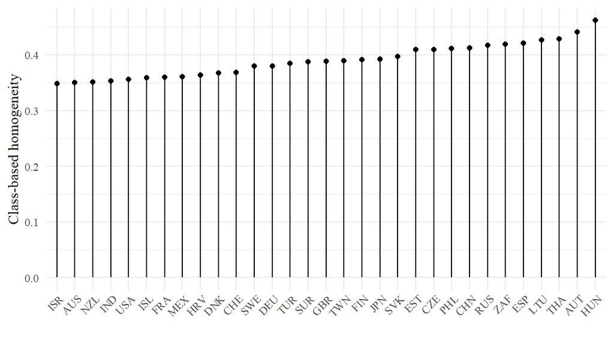

Figure 1: Class-based network homogeneity by country in the ISSP 2017

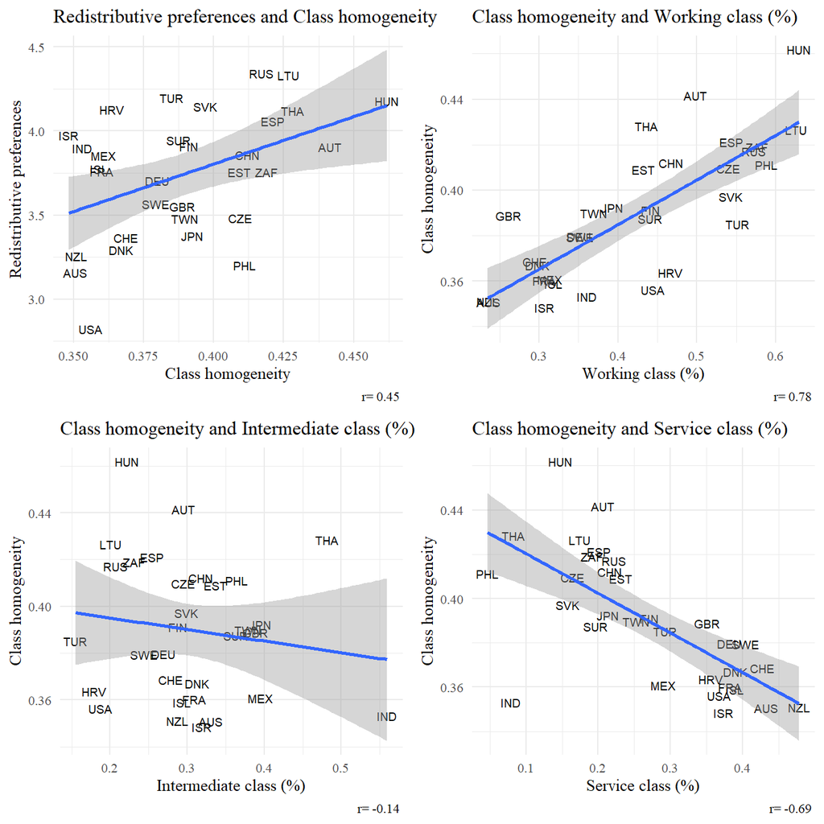

Figure 2: Redistribution, Network homogeneity and Social Class in the ISSP 2017

## Individual level

1. Class:
   - having a working class position is associated with higher redistributive preferences
   - class homogeneity is higher among the working class, and lower in the upper-class
2. Network segregation
   - being more segregated in terms of network homogeneity increase demand for redistribution
3. Network segregation x Social Class
   - The influence of homogeneity is positive among the working and intermediate classes, and negative among the upper class

Table 2: Multilevel regression for redistributive preferences, network homogeneity and social class

|  | Model 1 | Model 2 | Model 3 | Model 4 | Model 5 |
| --- | --- | --- | --- | --- | --- |
| Class-based network homogeneity | 0.18*** |  | 0.06* | 0.06* | -0.36*** |
|  | (0.02) |  | (0.03) | (0.03) | (0.06) |
| Social Class (ref: Service Class) |  |  |  |  |  |
| Intermediate Class |  | 0.09*** | 0.08*** | 0.05** | -0.08** |
|  |  | (0.02) | (0.02) | (0.02) | (0.03) |
| Working Class |  | 0.19*** | 0.18*** | 0.12*** | -0.05 |
|  |  | (0.01) | (0.02) | (0.02) | (0.03) |
| Income Tercile (ref: Low) |  |  |  |  |  |
| Middle |  |  |  | -0.11*** | -0.11*** |
|  |  |  |  | (0.02) | (0.02) |
| High |  |  |  | -0.21*** | -0.20*** |
|  |  |  |  | (0.02) | (0.02) |
| Education in years |  |  |  | -0.01*** | -0.00** |
|  |  |  |  | (0.00) | (0.00) |
| Not in labor force |  |  |  | 0.04** | 0.04** |
|  |  |  |  | (0.01) | (0.01) |
| Union membership: Yes |  |  |  | 0.14*** | 0.14*** |
|  |  |  |  | (0.01) | (0.01) |
| Homogeneity x Social Class |  |  |  |  |  |
| Homogeneity x Intermediate Class |  |  |  |  | 0.46*** |
|  |  |  |  |  | (0.08) |
| Homogeneity x Working Class |  |  |  |  | 0.55*** |
|  |  |  |  |  | (0.07) |
| Controls | No | No | No | Yes | Yes |
| BIC | 104173.60 | 104062.75 | 104011.33 | 103792.94 | 103761.73 |
| Num. obs. | 35150 | 35150 | 35150 | 35150 | 35150 |
| Num. Countries: | 31 | 31 | 31 | 31 | 31 |
| Var: Group | 0.14 | 0.13 | 0.13 | 0.14 | 0.14 |
| Var: Residual | 1.13 | 1.12 | 1.12 | 1.11 | 1.11 |

***p < 0.001; **p < 0.01; *p < 0.05

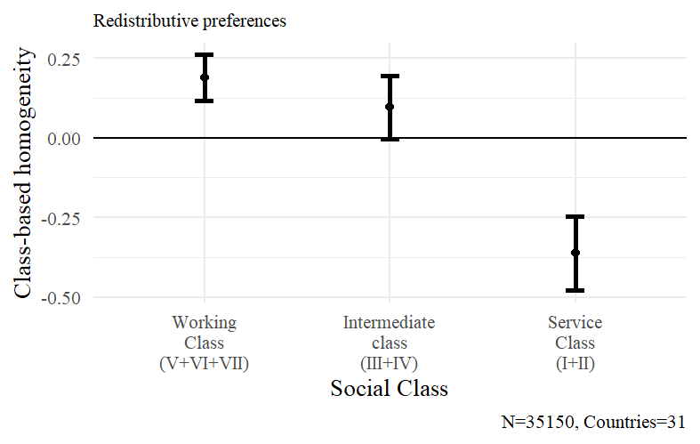

Figure 3: Conditional marginal effects of Network homogeneity on redistributive preferences

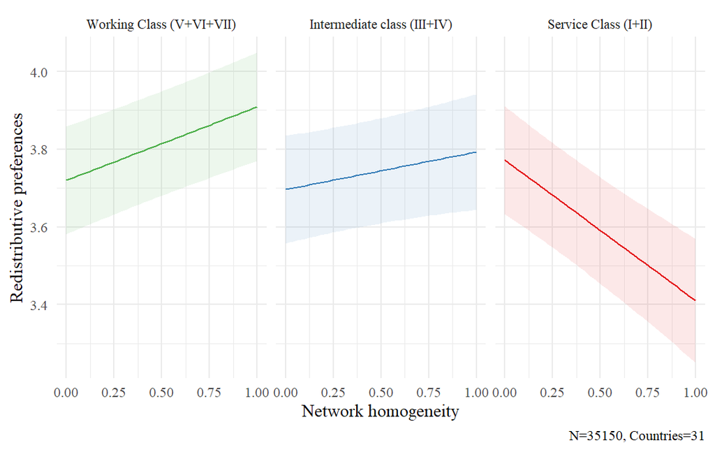

Figure 4: Conditional linear Predictions for network homogeneity on redistributive Preferences

## Macro level

- Expectation: Economic inequality increases segregation (maybe weak or null effect)
- Expectation: Economic inequality increase the influence of network homogeneity/segregation

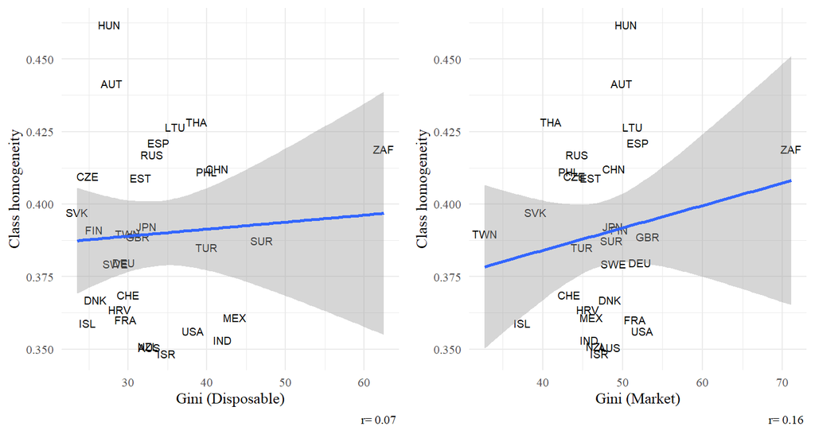

Figure 5: Network Homogeneity and Income Inequality in the ISSP 2017

Table 3: Cross-level interaction for Network homogeneity and Economic Inequality

|  | Model 1 | Model 2 | Model 3 | Model 4 | Model 5 | Model 6 |
| --- | --- | --- | --- | --- | --- | --- |
| Network Homogeneity | 0.05* | 0.07* | 0.15 | 0.05* | 0.07* | 0.05 |
|  | (0.03) | (0.03) | (0.12) | (0.03) | (0.03) | (0.20) |
| log GDP | -0.05 | -0.05 | -0.05 | -0.04 | -0.04 | -0.04 |
|  | (0.04) | (0.04) | (0.04) | (0.04) | (0.04) | (0.04) |
| Gini (Disposable) | 0.01 | 0.01 | 0.01 |  |  |  |
|  | (0.01) | (0.01) | (0.01) |  |  |  |
| Homogeneity x Gini (D) |  |  | -0.00 |  |  |  |
|  |  |  | (0.00) |  |  |  |
| Gini (Market) |  |  |  | 0.00 | 0.00 | 0.00 |
|  |  |  |  | (0.01) | (0.01) | (0.01) |
| Homogeneity x Gini (M) |  |  |  |  |  | 0.00 |
|  |  |  |  |  |  | (0.00) |
| BIC | 103824.56 | 103843.43 | 103862.94 | 103824.70 | 103843.58 | 103863.21 |
| Num. obs. | 35150 | 35150 | 35150 | 35150 | 35150 | 35150 |
| Num. groups: country2 | 31 | 31 | 31 | 31 | 31 | 31 |
| Var: country2 (Intercept) | 0.14 | 0.14 | 0.14 | 0.14 | 0.14 | 0.14 |
| Var: Residual | 1.11 | 1.11 | 1.11 | 1.11 | 1.11 | 1.11 |
| Var: country2 homclass |  | 0.01 | 0.01 |  | 0.01 | 0.01 |
| Cov: country2 (Intercept) homclass |  | 0.00 | 0.00 |  | 0.00 | 0.00 |

***p < 0.001; **p < 0.01; *p < 0.05

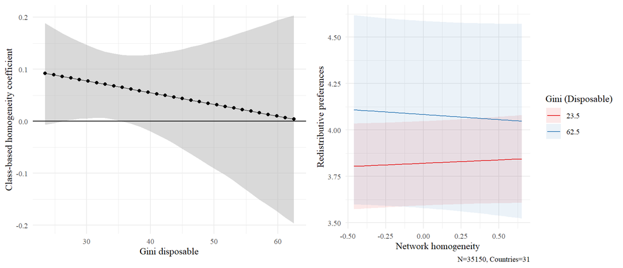

Figure 6: Cross-level interaction for Network homogeneity and Gini (Disposable)

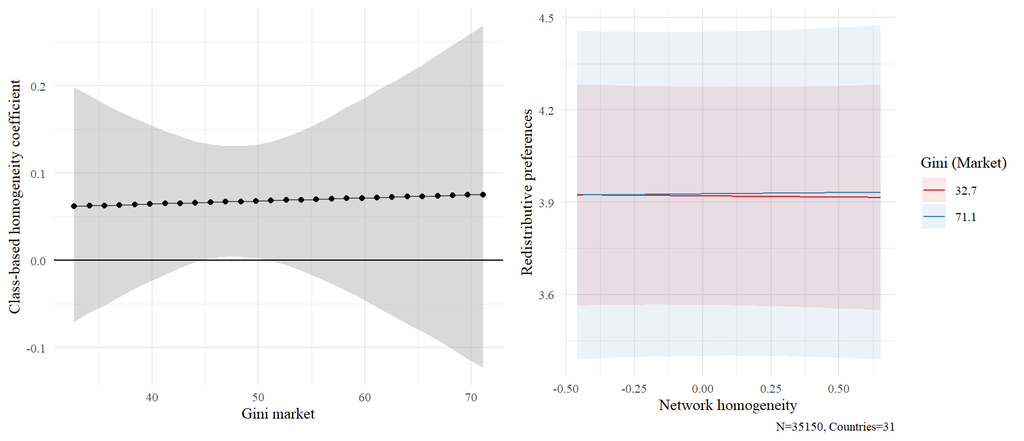

Figure 7: Cross-level interaction for Network homogeneity and Gini (Market)

# Additional analysis

- Homogeneity x other macro variables
- Network homogeneity (Strong ties)
- Network homogeneity (Weak ties)
- R’s and Partner social class
- Perceived Isolation

## Other macro variables

Source: https://www4.wider.unu.edu/?ind=1&type=ChoroplethSeq&year=70&byCountry=false&slider=buttons

- The **Palma ratio** is the share of all income received by the 10% people with highest disposable income divided by the share of all income received by the 40% people with the lowest disposable income.
- **90/10 ratio** = the ratio of Decile 10 income to Decile 1 income
- **90/50 ratio** = the ratio of Decile 10 income to Decile 5 income (the median)

Cross-level interaction for Network homogeneity and Economic Inequality

|  | Model 1 | Model 2 | Model 3 | Model 4 |
| --- | --- | --- | --- | --- |
| Class-based network homogeneity | 0.08 | 0.10 | 0.12 | 0.08* |
|  | (0.04) | (0.12) | (0.46) | (0.04) |
| log GDP | -0.04 | -0.04 | -0.04 | -0.04 |
|  | (0.04) | (0.04) | (0.04) | (0.04) |
| Palma Ratio | 0.02 |  |  |  |
|  | (0.04) |  |  |  |
| Share National Income - top 10% |  | 0.01 |  |  |
|  |  | (0.01) |  |  |
| Homogeneity x top 10 |  | -0.00 |  |  |
|  |  | (0.00) |  |  |
| Share National Income - bottom 50% |  |  | 0.00 |  |
|  |  |  | (0.02) |  |
| Homogeneity x bottom 50 |  |  | -0.00 |  |
|  |  |  | (0.01) |  |
| Ratio D10/D01 |  |  |  | 0.00 |
|  |  |  |  | (0.00) |
| Homogeneity x Ratio D10/D01 |  |  |  | -0.00 |
|  |  |  |  | (0.00) |
| AIC | 103688.52 | 103693.74 | 103691.03 | 103699.77 |
| BIC | 103857.87 | 103863.09 | 103860.37 | 103869.12 |
| Log Likelihood | -51824.26 | -51826.87 | -51825.51 | -51829.89 |
| Num. obs. | 35150 | 35150 | 35150 | 35150 |
| Num. groups: country2 | 31 | 31 | 31 | 31 |
| Var: country2 (Intercept) | 0.14 | 0.14 | 0.14 | 0.14 |
| Var: country2 homclass | 0.01 | 0.01 | 0.01 | 0.01 |
| Cov: country2 (Intercept) homclass | 0.00 | 0.00 | 0.00 | 0.00 |
| Var: Residual | 1.11 | 1.11 | 1.11 | 1.11 |

***p < 0.001; **p < 0.01; *p < 0.05

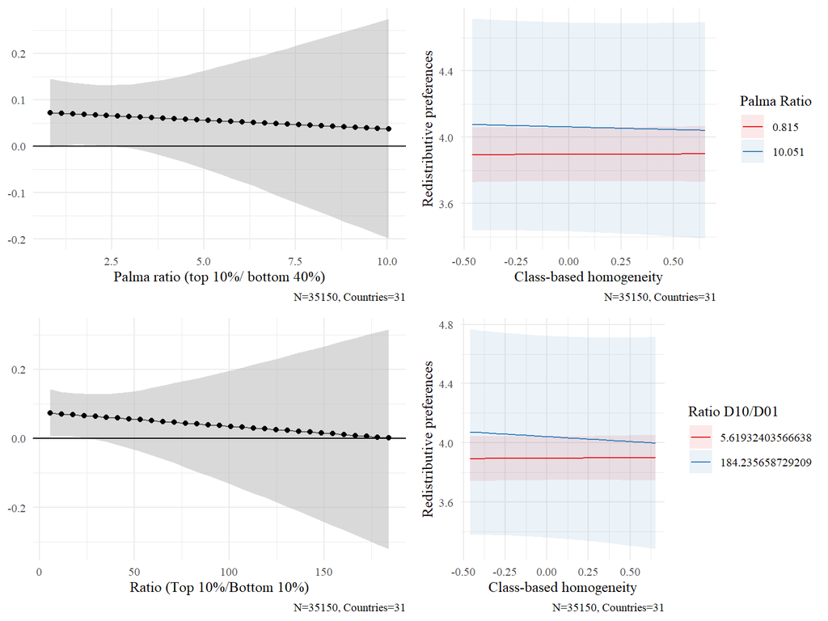

Figure 8: Cross-level interaction for Network homogeneity and Economic Inequality

## Strong ties

Table 2: Multilevel regression for redistributive preferences, network homogeneity (strong) and social class

|  | Model 1 | Model 2 | Model 3 | Model 4 | Model 5 |
| --- | --- | --- | --- | --- | --- |
| Class-based network homogeneity (Strong) | 0.08*** |  | 0.02 | 0.02 | -0.22*** |
|  | (0.02) |  | (0.02) | (0.02) | (0.04) |
| Social Class (ref: Service Class) |  |  |  |  |  |
| Intermediate class |  | 0.08*** | 0.08*** | 0.05** | -0.01 |
|  |  | (0.02) | (0.02) | (0.02) | (0.02) |
| Working Class |  | 0.18*** | 0.18*** | 0.12*** | 0.01 |
|  |  | (0.02) | (0.02) | (0.02) | (0.02) |
| Income Tercile (ref: Low) |  |  |  |  |  |
| Middle |  |  |  | -0.13*** | -0.13*** |
|  |  |  |  | (0.02) | (0.02) |
| High |  |  |  | -0.23*** | -0.22*** |
|  |  |  |  | (0.02) | (0.02) |
| Education in years |  |  |  | -0.00** | -0.00 |
|  |  |  |  | (0.00) | (0.00) |
| Not in labor force |  |  |  | 0.05** | 0.05** |
|  |  |  |  | (0.02) | (0.02) |
| Union membership: Yes |  |  |  | 0.15*** | 0.15*** |
|  |  |  |  | (0.01) | (0.01) |
| Homogeneity x Social Class |  |  |  |  |  |
| Homogeneity x Intermediate class |  |  |  |  | 0.24*** |
|  |  |  |  |  | (0.06) |
| Homogeneity x Working Class |  |  |  |  | 0.36*** |
|  |  |  |  |  | (0.05) |
| Controls | No | No | No | Yes | Yes |
| BIC | 91956.95 | 91844.50 | 91817.68 | 91608.53 | 91588.56 |
| Num. obs. | 30832 | 30832 | 30832 | 30832 | 30832 |
| Num. Countries: | 31 | 31 | 31 | 31 | 31 |
| Var: Group | 0.14 | 0.13 | 0.14 | 0.14 | 0.14 |
| Var: Residual | 1.15 | 1.14 | 1.14 | 1.13 | 1.13 |

***p < 0.001; **p < 0.01; *p < 0.05

## Weak ties

Table 2: Multilevel regression for redistributive preferences, network homogeneity (weak) and social class

|  | Model 1 | Model 2 | Model 3 | Model 4 | Model 5 |
| --- | --- | --- | --- | --- | --- |
| Class-based network homogeneity (Weak) | 0.07*** |  | -0.01 | -0.01 | -0.12** |
|  | (0.02) |  | (0.02) | (0.02) | (0.04) |
| Social Class (ref: Service Class) |  |  |  |  |  |
| Intermediate class |  | 0.08*** | 0.08*** | 0.04** | 0.01 |
|  |  | (0.02) | (0.02) | (0.02) | (0.02) |
| Working Class |  | 0.20*** | 0.20*** | 0.14*** | 0.09*** |
|  |  | (0.02) | (0.02) | (0.02) | (0.02) |
| Income Tercile (ref: Low) |  |  |  |  |  |
| Middle |  |  |  | -0.11*** | -0.11*** |
|  |  |  |  | (0.02) | (0.02) |
| High |  |  |  | -0.20*** | -0.20*** |
|  |  |  |  | (0.02) | (0.02) |
| Education in years |  |  |  | -0.01*** | -0.01*** |
|  |  |  |  | (0.00) | (0.00) |
| Not in labor force |  |  |  | 0.04* | 0.04* |
|  |  |  |  | (0.02) | (0.02) |
| Union membership: Yes |  |  |  | 0.15*** | 0.15*** |
|  |  |  |  | (0.01) | (0.01) |
| Homogeneity x Social Class |  |  |  |  |  |
| Homogeneity x Intermediate class |  |  |  |  | 0.12* |
|  |  |  |  |  | (0.06) |
| Homogeneity x Working Class |  |  |  |  | 0.15** |
|  |  |  |  |  | (0.05) |
| Controls | No | No | No | Yes | Yes |
| BIC | 86787.64 | 86653.17 | 86634.36 | 86475.51 | 86495.33 |
| Num. obs. | 29309 | 29309 | 29309 | 29309 | 29309 |
| Num. Countries: | 31 | 31 | 31 | 31 | 31 |
| Var: Group | 0.14 | 0.13 | 0.13 | 0.14 | 0.14 |
| Var: Residual | 1.12 | 1.12 | 1.11 | 1.10 | 1.10 |

***p < 0.001; **p < 0.01; *p < 0.05

## Respondent class

Table 2: Multilevel regression for redistributive preferences, network homogeneity and Own social class

|  | Model 1 | Model 2 | Model 3 | Model 4 | Model 5 | Model 6 |
| --- | --- | --- | --- | --- | --- | --- |
| Class-based network homogeneity | 0.24*** |  | 0.12** | 0.09* | 0.06 | -0.23** |
|  | (0.04) |  | (0.04) | (0.04) | (0.04) | (0.07) |
| Social Class - Resp. (ref: Service Class) |  |  |  |  |  |  |
| Intermediate class |  | 0.12*** | 0.10*** | 0.07*** | 0.07** | -0.10* |
|  |  | (0.02) | (0.02) | (0.02) | (0.02) | (0.04) |
| Working Class |  | 0.21*** | 0.20*** | 0.14*** | 0.13*** | -0.00 |
|  |  | (0.02) | (0.02) | (0.02) | (0.02) | (0.05) |
| Income Tercile (ref: Low) |  |  |  |  |  |  |
| Middle |  |  |  | -0.13*** | -0.13*** | -0.13*** |
|  |  |  |  | (0.02) | (0.02) | (0.02) |
| High |  |  |  | -0.23*** | -0.22*** | -0.22*** |
|  |  |  |  | (0.02) | (0.02) | (0.02) |
| Education in years |  |  |  | -0.00* | -0.00 | -0.00 |
|  |  |  |  | (0.00) | (0.00) | (0.00) |
| Not in labor force |  |  |  | 0.03 | 0.02 | 0.02 |
|  |  |  |  | (0.02) | (0.02) | (0.02) |
| Union membership: Yes |  |  |  | 0.13*** | 0.13*** | 0.13*** |
|  |  |  |  | (0.02) | (0.02) | (0.02) |
| Homogeneity x Social Class |  |  |  |  |  |  |
| Homogeneity x Intermediate class |  |  |  |  |  | 0.47*** |
|  |  |  |  |  |  | (0.10) |
| Homogeneity x Working Class |  |  |  |  |  | 0.36*** |
|  |  |  |  |  |  | (0.10) |
| Intermediate Class (Partner) |  |  |  |  | 0.02 | 0.03 |
|  |  |  |  |  | (0.02) | (0.02) |
| Working Class (Partner) |  |  |  |  | 0.09*** | 0.09*** |
|  |  |  |  |  | (0.02) | (0.02) |
| Controls | No | No | No | Yes | Yes | Yes |
| BIC | 54663.93 | 54609.24 | 54607.78 | 54546.92 | 54560.07 | 54561.68 |
| Num. obs. | 18270 | 18270 | 18270 | 18270 | 18270 | 18270 |
| Num. Countries: | 31 | 31 | 31 | 31 | 31 | 31 |
| Var: Group | 0.15 | 0.15 | 0.15 | 0.15 | 0.15 | 0.15 |
| Var: Residual | 1.16 | 1.15 | 1.15 | 1.14 | 1.14 | 1.13 |

***p < 0.001; **p < 0.01; *p < 0.05

## Gov’s spending and individualism

Cross-level interaction for Network homogeneity, Goverment Spending and Individualism

|  | Model 1 | Model 2 |
| --- | --- | --- |
| Class-based network homogeneity | 0.06 | -0.05 |
|  | (0.08) | (0.11) |
| log GDP | -0.06* | -0.04 |
|  | (0.03) | (0.04) |
| Individualism Index* | -1.00*** |  |
|  | (0.25) |  |
| Homogeneity x Individualism | 0.02 |  |
|  | (0.14) |  |
| Gov. Spending (% GDP)* |  | -0.00 |
|  |  | (0.01) |
| Homogeneity x Gov. Spend. |  | 0.00 |
|  |  | (0.00) |
| AIC | 103667.52 | 103694.52 |
| BIC | 103836.86 | 103863.87 |
| Log Likelihood | -51813.76 | -51827.26 |
| Num. obs. | 35150 | 35150 |
| Num. groups: country2 | 31 | 31 |
| Var: country2 (Intercept) | 0.09 | 0.14 |
| Var: country2 homclass | 0.01 | 0.01 |
| Cov: country2 (Intercept) homclass | 0.00 | 0.00 |
| Var: Residual | 1.11 | 1.11 |

***p < 0.001; **p < 0.01; *p < 0.05

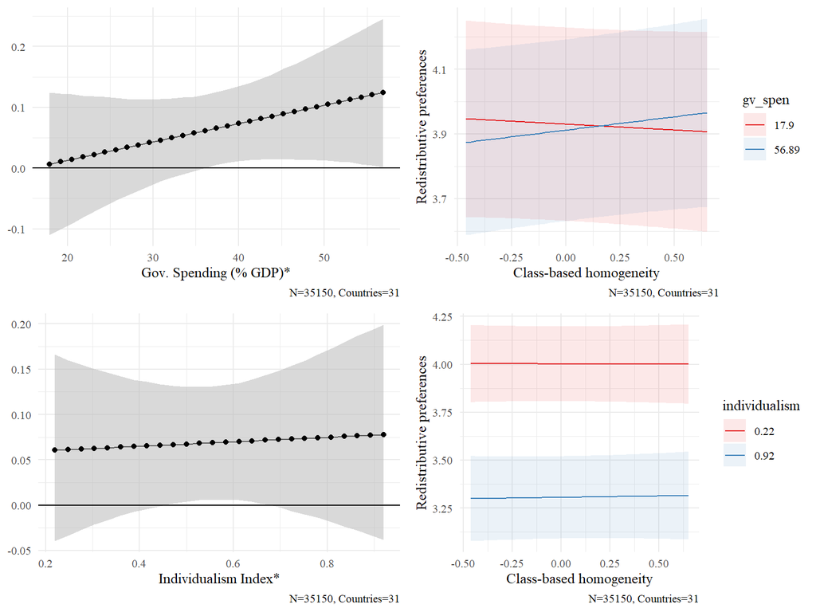

Figure 9: Cross-level interaction for Network homogeneity, Gov. Spending and Individualism

## Perceived Isolation

Table 2: Multilevel regression for redistributive preferences, social isolation and social class

|  | Model 1 | Model 2 | Model 3 | Model 4 | Model 5 |
| --- | --- | --- | --- | --- | --- |
| Perceived Isolation | 0.03*** |  | 0.03*** | 0.03*** | 0.06*** |
|  | (0.01) |  | (0.01) | (0.01) | (0.01) |
| Social Class (ref: Service Class) |  |  |  |  |  |
| Intermediate Class |  | 0.09*** | 0.08*** | 0.05** | 0.11** |
|  |  | (0.02) | (0.02) | (0.02) | (0.03) |
| Working Class |  | 0.19*** | 0.18*** | 0.12*** | 0.22*** |
|  |  | (0.01) | (0.02) | (0.02) | (0.03) |
| Income Tercile (ref: Low) |  |  |  |  |  |
| Middle |  |  |  | -0.11*** | -0.11*** |
|  |  |  |  | (0.02) | (0.02) |
| High |  |  |  | -0.21*** | -0.21*** |
|  |  |  |  | (0.02) | (0.02) |
| Education in years |  |  |  | -0.01** | -0.00** |
|  |  |  |  | (0.00) | (0.00) |
| Not in labor force |  |  |  | 0.04** | 0.04** |
|  |  |  |  | (0.01) | (0.01) |
| Union membership: Yes |  |  |  | 0.14*** | 0.14*** |
|  |  |  |  | (0.01) | (0.01) |
| Isolation x Social Class |  |  |  |  |  |
| Homogeneity x Intermediate Class |  |  |  |  | -0.03* |
|  |  |  |  |  | (0.02) |
| Homogeneity x Working Class |  |  |  |  | -0.06*** |
|  |  |  |  |  | (0.02) |
| Class-based network homogeneity | 0.18*** |  | 0.06* | 0.06* | 0.06* |
|  | (0.02) |  | (0.03) | (0.03) | (0.03) |
| Controls | No | No | No | Yes | Yes |
| BIC | 103771.44 | 103669.72 | 103614.77 | 103402.87 | 103424.08 |
| Num. obs. | 35018 | 35018 | 35018 | 35018 | 35018 |
| Num. Countries: | 31 | 31 | 31 | 31 | 31 |
| Var: Group | 0.14 | 0.13 | 0.14 | 0.14 | 0.14 |
| Var: Residual | 1.13 | 1.12 | 1.12 | 1.11 | 1.11 |

***p < 0.001; **p < 0.01; *p < 0.05

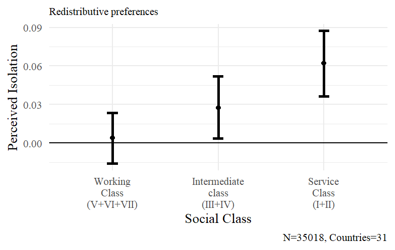

Figure 10: Conditional marginal effects of Perceived Isolation on redistributive preferences

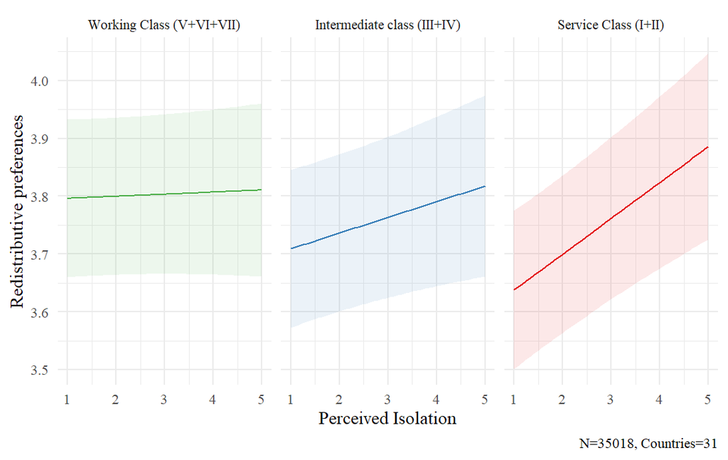

Figure 11: Predictions for Redistributive Preferences

Table 3: Cross-level interaction for Perceived Isolation and Economic Inequality

|  | Model 1 | Model 2 | Model 3 | Model 4 | Model 5 | Model 6 |
| --- | --- | --- | --- | --- | --- | --- |
| Perceived Isolation | 0.03*** | 0.02 | 0.17* | 0.03*** | 0.02 | -0.04 |
|  | (0.01) | (0.02) | (0.07) | (0.01) | (0.02) | (0.14) |
| log GDP | -0.05 | -0.04 | -0.04 | -0.04 | -0.05 | -0.05 |
|  | (0.04) | (0.03) | (0.03) | (0.04) | (0.03) | (0.03) |
| Gini (Disposable) | 0.01 | -0.00 | 0.01 |  |  |  |
|  | (0.01) | (0.01) | (0.01) |  |  |  |
| Isolation x Gini (D) |  |  | -0.00* |  |  |  |
|  |  |  | (0.00) |  |  |  |
| Gini (Market) |  |  |  | 0.00 | 0.00 | -0.00 |
|  |  |  |  | (0.01) | (0.01) | (0.01) |
| Isolation x Gini (M) |  |  |  |  |  | 0.00 |
|  |  |  |  |  |  | (0.00) |
| BIC | 103434.41 | 103340.72 | 103357.44 | 103423.58 | 103328.92 | 103349.03 |
| Num. obs. | 35018 | 35018 | 35018 | 35018 | 35018 | 35018 |
| Num. groups: country2 | 31 | 31 | 31 | 31 | 31 | 31 |
| Var: country2 (Intercept) | 0.14 | 0.25 | 0.24 | 0.14 | 0.25 | 0.25 |
| Var: Residual | 1.11 | 1.10 | 1.10 | 1.11 | 1.10 | 1.10 |
| Var: country2 isolation |  | 0.01 | 0.01 |  | 0.01 | 0.01 |
| Cov: country2 (Intercept) isolation |  | -0.04 | -0.03 |  | -0.04 | -0.04 |

***p < 0.001; **p < 0.01; *p < 0.05

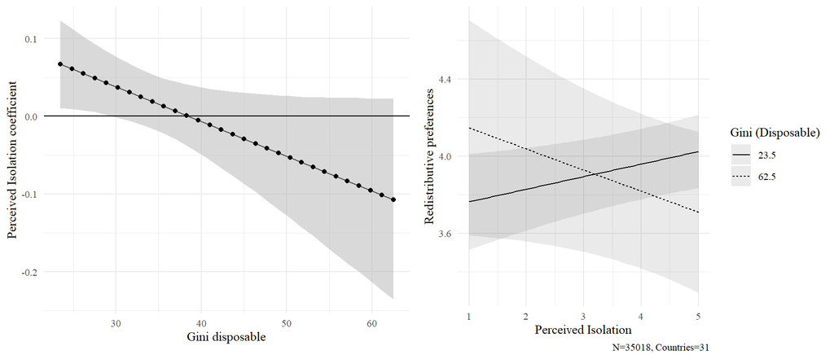

Figure 12: Cross-level interaction for Perceived Isolation and Gini (Disposable)

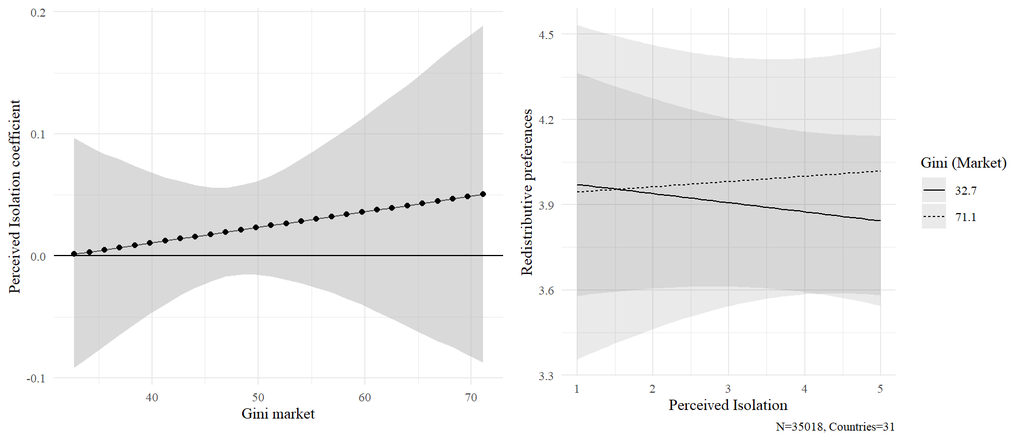

Figure 13: Cross-level interaction for Perceived Isolation and Gini (Market)

# References

Beck, G. (2019). *Explorando la asociación entre redes de contacto ocupacionales y la justificación de la desigualdad social en Chile* (Master’s thesis). Pontificia Universidad Católica de Chile, Santiago de Chile.

Bourdieu, P. (1984). *Distinction: A social critique of the judgement of taste*. Cambridge, MA: Harvard University Press.

Bourdieu, P., & Passeron, J.-C. (1981). *La Reproducción: Elementos Para Una Teoría Del Sistema de Enseñanza.* Laia Barcelona.

Carrascosa, J. (2023). Class inequalities in access to social capital in the metropolitan area of Buenos Aires. *Social Networks*, *72*, 59–69. https://doi.org/10.1016/j.socnet.2022.09.003

Cepić, D., & Tonković, Ž. (2020). How social ties transcend class boundaries? Network variability as tool for exploring occupational homophily. *Social Networks*, *62*, 33–42. https://doi.org/10.1016/j.socnet.2020.02.003

Edlund, J., & Lindh, A. (2015). The democratic class struggle revisited: The welfare state, social cohesion and political conflict. *Acta Sociologica*, *58*(4), 311–328. https://doi.org/10.1177/0001699315610176

Ganzeboom, H. B. G., & Treiman, D. J. (1996). Internationally Comparable Measures of Occupational Status for the 1988 International Standard Classification of Occupations. *Social Science Research*, *25*(3), 201–239. https://doi.org/10.1006/ssre.1996.0010

Goldthorpe, J. (1992). Sobre la clase de servicio, su formación y su futuro. In J. Carabaña & A. de Francisco (Eds.), *Teorías contemporáneas de las clases sociales* (pp. 229–263). Madrid: Editorial Pablo Iglesias.

Joye, D., Sapin, M., & Wolf, C. (2019). *Measuring social networks and social resources: an exploratory ISSP survey around the world*. Köln: GESIS - Leibniz- Institut für Sozialwissenschaften.

Lee, J. (2023). Consider your origins: Parental social class and preferences for redistribution in the United States from 1977 to 2018. *Social Science Research*, *110*, 102840. https://doi.org/10.1016/j.ssresearch.2022.102840

Lin, N., & Erickson, B. (2008). Theory, Measurement, and the Research Enterprise on Social Capital. In N. Lin & B. H. Erickson (Eds.), *Social Capital: An International Research Program* (p. 0). Oxford University Press. https://doi.org/10.1093/acprof:oso/9780199234387.003.0010

Lindh, A., Andersson, A. B., & Volker, B. (2021). The Missing Link: Network Influences on Class Divides in Political Attitudes. *European Sociological Review*, *37*(5), 695–712. https://doi.org/10.1093/esr/jcab010

Lindh, A., & McCall, L. (2020). Class Position and Political Opinion in Rich Democracies. *Annual Review of Sociology*, *46*(1), 419–441. https://doi.org/10.1146/annurev-soc-121919-054609

Londoño-Vélez, J. (2022). The impact of diversity on perceptions of income distribution and preferences for redistribution. *Journal of Public Economics*, *214*, 104732. https://doi.org/10.1016/j.jpubeco.2022.104732

Nathan, N. L., & Sands, M. L. (2023). Context and Contact: Unifying the Study of Environmental Effects on Politics. *Annual Review of Political Science*, *26*(1), null. https://doi.org/10.1146/annurev-polisci-051421-012551

Otero, G., Volker, B., & Rozer, J. (2021). Open But Segregated? Class Divisions And the Network Structure of Social Capital in Chile. *Social Forces*, *100*(2), 649–679. https://doi.org/10.1093/sf/soab005

Paskov, M., & Weisstanner, D. (2022). Cross-Class Embeddedness through Family Ties and Support for Income Redistribution. *European Sociological Review*, *38*(2), 286–303. https://doi.org/10.1093/esr/jcab040

Pettigrew, T. F. (1998). Intergroup Contact Theory. *Annual Review of Psychology*, *49*(1), 65–85. https://doi.org/10.1146/annurev.psych.49.1.65

Pichler, F., & Wallace, C. (2009). Social Capital and Social Class in Europe: The Role of Social Networks in Social Stratification. *European Sociological Review*, *25*(3), 319–332. https://doi.org/10.1093/esr/jcn050

Svallfors, S. (2006). *The moral economy of class: Class and attitudes in comparative perspective*. Stanford University Press. https://doi.org/10.1515/9781503625624

Volker, B. (2020). Social capital across the life course: Accumulation, diminution, or segregation? *Network Science*, *8*(3), 313–332. https://doi.org/10.1017/nws.2020.26

Weber, M. (1978). *Economy and society: An outline of interpretative sociology*. Berkeley London: University of California press. (Original work published 1922).

Wright, E. O., & Cho, D. (1992). The Relative Permeability of Class Boundaries to Cross-Class Friendships: A Comparative Study of the United States, Canada, Sweden, and Norway. *American Sociological Review*, *57*(1), 85–102. https://doi.org/10.2307/2096146

Yamamura, E. (2012). Social capital, household income, and preferences for income redistribution. *European Journal of Political Economy*, *28*(4), 498–511. https://doi.org/10.1016/j.ejpoleco.2012.05.010

# Appendix

[output not shown]

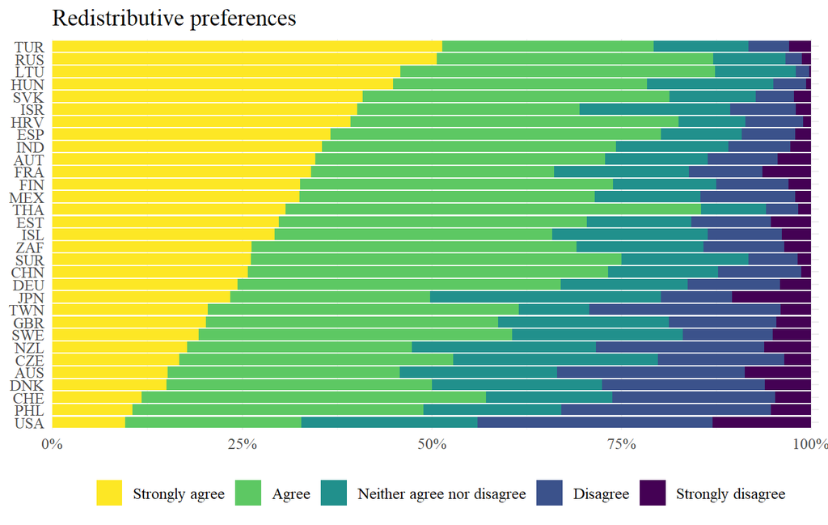

Figure 14: Redistributive preferences by country in the ISSP 2017